# Association Rules in DOTA 2 Hero Drafting

# Association Rules in DOTA 2

## Background and Data Import

After manipulation in Python, the imported csv contains approx 100,000 teams (99,930) from 50,000 matches, each with 5 heroes in each team

```r
set.seed(123)
team_df <- read_csv("Hero_Drafting.csv")
team_df
```

| team_id | localized_name |
| --- | --- |
| 0 | Rubick, Clockwerk, Treant Protector, Shadow Fiend, Spectre |
| 1 | Earthshaker, Meepo, Spirit Breaker, Queen of Pain, Windranger |
| 2 | Clockwerk, Terrorblade, Mirana, Faceless Void, Shadow Shaman |
| 3 | Dazzle, Phantom Assassin, Riki, Lion, Queen of Pain |
| 4 | Juggernaut, Queen of Pain, Dark Seer, Disruptor, Doom |
| 5 | Riki, Shadow Shaman, Spectre, Ember Spirit, Spirit Breaker |
| 6 | Vengeful Spirit, Juggernaut, Spectre, Doom, Tusk |
| 7 | Nature's Prophet, Phantom Assassin, Centaur Warrunner, Pudge, Invoker |
| 8 | Phantom Assassin, Slardar, Undying, Zeus, Witch Doctor |
| 9 | Enchantress, Slardar, Phantom Assassin, Rubick, Queen of Pain |

[output cut: 990 more lines]

Splitting the hero names into lists and converting to a transactions data type

```r
items <- strsplit(as.character(team_df$localized_name), ", ")
transactions_dota = as(items, Class = 'transactions')
```

A basic overview of the data set is below

```r
# get the basic overview of the dataset
summary(transactions_dota)
```

```
transactions as itemMatrix in sparse format with
 99930 rows (elements/itemsets/transactions) and
 110 columns (items) and a density of 0.04545455

most frequent items:
  Windranger Shadow Fiend      Invoker  Earthshaker      Slardar      (Other)
       20869        16993        11668        11317        11174       427629

element (itemset/transaction) length distribution:
sizes
    5
99930

   Min. 1st Qu.  Median    Mean 3rd Qu.    Max.
      5       5       5       5       5       5

includes extended item information - examples:
```

|  | labels |
| --- | --- |
| 1 | Abaddon |
| 2 | Alchemist |
| 3 | Ancient Apparition |

## Basic views of the transactions Database

```r
# look at the first five transactions
inspect(transactions_dota[1:5])
```

|  | items |
| --- | --- |
| [1] | {Clockwerk,Rubick,Shadow Fiend,Spectre,Treant Protector} |
| [2] | {Earthshaker,Meepo,Queen of Pain,Spirit Breaker,Windranger} |
| [3] | {Clockwerk,Faceless Void,Mirana,Shadow Shaman,Terrorblade} |
| [4] | {Dazzle,Lion,Phantom Assassin,Queen of Pain,Riki} |
| [5] | {Dark Seer,Disruptor,Doom,Juggernaut,Queen of Pain} |

```r
# examining the frequency of the first few items
itemFrequency(transactions_dota[, 1:3])
```

```
           Abaddon          Alchemist Ancient Apparition
        0.03310317         0.09822876         0.06752727
```

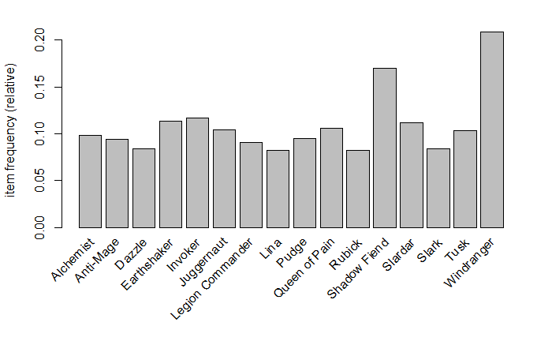

```r
# viewing frequencies of heroes that appear in more that 8% of teams
itemFrequencyPlot(transactions_dota, support = 0.08)
```

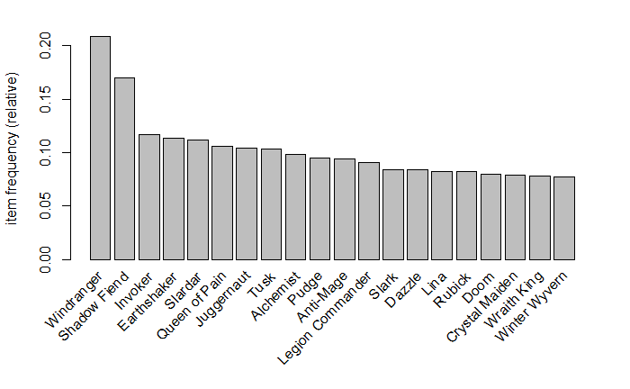

```r
# plotting frequency of the top 20 heroes
itemFrequencyPlot(transactions_dota, topN = 20)
```

## Mining Association Rules

Mining associations with Apriori results in 5,290 association rules  
The parameters have been set to be very low, so as to capture as many association rules as possible, even for less popular heroes  
The most significant rules will visible graphically, where the significance of a rule in this context will be determined by the support and lift.  
The support is the probability of itemset occurring together.  
The lift is the value of the interaction between itemset A and B, i.e. the factor of enhanced response. It is the increased rate of picking itemset B after itemset A compared to the independent probability of picking itemset B

```r
# performing with a very low support to caputre many rules
# suppot of 0.001 translates to approx 100 games out of 99,930
# confidence of 0.025 translates to the probability of itemset B appearing, given that itemset A has appeared, is 2.5%
# minlength of items transates to the rule containing at least 2 items
dota_rules <- apriori(transactions_dota, parameter = list(support =
                          0.001, confidence = 0.025, minlen = 2))
```

```
Apriori

Parameter specification:
```

|  | confidence | minval | smax | arem | aval | originalSupport | maxtime | support | minlen | maxlen | target | ext |
| --- | --- | --- | --- | --- | --- | --- | --- | --- | --- | --- | --- | --- |
|  | 0.025 | 0.1 | 1 | none | FALSE | TRUE | 5 | 0.001 | 2 | 10 | rules | FALSE |

```
Algorithmic control:
```

|  | filter | tree | heap | memopt | load | sort | verbose |
| --- | --- | --- | --- | --- | --- | --- | --- |
|  | 0.1 | TRUE | TRUE | FALSE | TRUE | 2 | TRUE |

```
Absolute minimum support count: 99

set item appearances ...[0 item(s)] done [0.00s].
set transactions ...[110 item(s), 99930 transaction(s)] done [0.04s].
sorting and recoding items ... [110 item(s)] done [0.00s].
creating transaction tree ... done [0.06s].
checking subsets of size 1 2 3 4 done [0.03s].
writing ... [5290 rule(s)] done [0.00s].
creating S4 object  ... done [0.02s].
```

```r
dota_rules
```

```
set of 5290 rules
```

Mining has resulted in:  
* 4,486 rules that contain 2 items  
* 804 rules that contain 3 items

```r
# summary of dota association rules
summary(dota_rules)
```

```
set of 5290 rules

rule length distribution (lhs + rhs):sizes
   2    3
4486  804

   Min. 1st Qu.  Median    Mean 3rd Qu.    Max.
  2.000   2.000   2.000   2.152   2.000   3.000

summary of quality measures:
    support           confidence           lift            count
 Min.   :0.001001   Min.   :0.02500   Min.   :0.1519   Min.   : 100.0
 1st Qu.:0.001341   1st Qu.:0.04113   1st Qu.:0.7569   1st Qu.: 134.0
 Median :0.002081   Median :0.06336   Median :0.8755   Median : 208.0
 Mean   :0.003021   Mean   :0.06978   Mean   :0.8681   Mean   : 301.9
 3rd Qu.:0.003603   3rd Qu.:0.08297   3rd Qu.:0.9711   3rd Qu.: 360.0
 Max.   :0.022946   Max.   :0.31719   Max.   :5.9805   Max.   :2293.0

mining info:
```

|  | data | ntransactions | support | confidence |
| --- | --- | --- | --- | --- |
|  | transactions_dota | 99930 | 0.001 | 0.025 |

We can see that the highest interactions mines below.  
As an example, the top row shows:  
* Tiny and IO appear together in 0.537% of game  
* The probability of picking IO after Tiny is 10.1% (Second row shows the probability of picking Tiny after IO is 31.7%)  
* The lift shows that the increase in the probability of picking IO after picking tiny from the probability of picking IO independently, is 5.98 times

The remaining 10 rows in the table also show rules with very high value interactions

```r
# sorting DOTA rules by lift, and displaying first 10 rules
dota_rules <- sort(dota_rules, by="lift")
inspect(dota_rules[1:10])
```

|  | lhs |  | rhs | support | confidence | lift | count |
| --- | --- | --- | --- | --- | --- | --- | --- |
| [1] | {Tiny} | => | {Io} | 0.005373762 | 0.10132075 | 5.980498 | 537 |
| [2] | {Io} | => | {Tiny} | 0.005373762 | 0.31718842 | 5.980498 | 537 |
| [3] | {Huskar,Slardar} | => | {Dazzle} | 0.001010707 | 0.27297297 | 3.247403 | 101 |
| [4] | {Huskar,Shadow Fiend} | => | {Dazzle} | 0.001190834 | 0.24040404 | 2.859949 | 119 |
| [5] | {Io} | => | {Chaos Knight} | 0.001060743 | 0.06261075 | 2.670377 | 106 |
| [6] | {Chaos Knight} | => | {Io} | 0.001060743 | 0.04524114 | 2.670377 | 106 |
| [7] | {Huskar} | => | {Dazzle} | 0.007745422 | 0.20470775 | 2.435291 | 774 |
| [8] | {Dazzle} | => | {Huskar} | 0.007745422 | 0.09214286 | 2.435291 | 774 |
| [9] | {Huskar,Windranger} | => | {Dazzle} | 0.001110778 | 0.19170984 | 2.280662 | 111 |
| [10] | {Dazzle,Slardar} | => | {Huskar} | 0.001010707 | 0.08466052 | 2.237537 | 101 |

We can see that 622 rules are redundant (less predictive than a more general rule)

```r
# finding and removing any redundant rules
# A rule is redundant if a more general rules with the same or a higher confidence exists, as it would be equally or less predictive than a more general rule. A rule is more general if it has the same RHS but one or more items removed from the LHS. Formally, a rule X -> Y is redundant if
# for some X' subset X, conf(X' -> Y) >= conf(X -> Y).
print(sum(is.redundant(dota_rules)))
```

```
[1] 622
```

```r
inspect(dota_rules[is.redundant(dota_rules)][1:10])
```

|  | lhs |  | rhs | support | confidence | lift | count |
| --- | --- | --- | --- | --- | --- | --- | --- |
| [1] | {Huskar,Windranger} | => | {Dazzle} | 0.001110778 | 0.19170984 | 2.280662 | 111 |
| [2] | {Dazzle,Slardar} | => | {Huskar} | 0.001010707 | 0.08466052 | 2.237537 | 101 |
| [3] | {Dazzle,Shadow Fiend} | => | {Huskar} | 0.001190834 | 0.07965194 | 2.105162 | 119 |
| [4] | {Dazzle,Windranger} | => | {Huskar} | 0.001110778 | 0.06723198 | 1.776909 | 111 |
| [5] | {Lich,Windranger} | => | {Doom} | 0.001050736 | 0.11904762 | 1.500180 | 105 |
| [6] | {Doom,Windranger} | => | {Lich} | 0.001050736 | 0.07004670 | 1.495357 | 105 |
| [7] | {Omniknight,Windranger} | => | {Phantom Assassin} | 0.001130792 | 0.10610329 | 1.457243 | 113 |
| [8] | {Queen of Pain,Slardar} | => | {Dazzle} | 0.001180827 | 0.10582960 | 1.258994 | 118 |
| [9] | {Crystal Maiden,Windranger} | => | {Juggernaut} | 0.001781247 | 0.12491228 | 1.202088 | 178 |
| [10] | {Dazzle,Queen of Pain} | => | {Slardar} | 0.001180827 | 0.13096559 | 1.171236 | 118 |

```r
## removing any redundant rules
dota_rules <- dota_rules[!is.redundant(dota_rules)]
inspect(dota_rules)
```

|  | lhs |  | rhs | support | confidence | lift | count |
| --- | --- | --- | --- | --- | --- | --- | --- |
| [1] | {Tiny} | => | {Io} | 0.005373762 | 0.10132075 | 5.9804979 | 537 |
| [2] | {Io} | => | {Tiny} | 0.005373762 | 0.31718842 | 5.9804979 | 537 |
| [3] | {Huskar,Slardar} | => | {Dazzle} | 0.001010707 | 0.27297297 | 3.2474035 | 101 |
| [4] | {Huskar,Shadow Fiend} | => | {Dazzle} | 0.001190834 | 0.24040404 | 2.8599495 | 119 |
| [5] | {Io} | => | {Chaos Knight} | 0.001060743 | 0.06261075 | 2.6703766 | 106 |
| [6] | {Chaos Knight} | => | {Io} | 0.001060743 | 0.04524114 | 2.6703766 | 106 |
| [7] | {Huskar} | => | {Dazzle} | 0.007745422 | 0.20470775 | 2.4352911 | 774 |
| [8] | {Dazzle} | => | {Huskar} | 0.007745422 | 0.09214286 | 2.4352911 | 774 |
| [9] | {Drow Ranger} | => | {Vengeful Spirit} | 0.002261583 | 0.08672295 | 2.0668314 | 226 |
| [10] | {Vengeful Spirit} | => | {Drow Ranger} | 0.002261583 | 0.05389936 | 2.0668314 | 226 |

[output cut: 990 more lines]

## Analysis of Association Rules

### All Rules

Plotting 50 highest lift rules with arulesViz results in a somewhat difficult to read graph

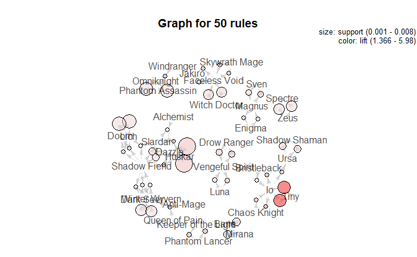

```r
plot(dota_rules[1:50], method="graph")
```

Gephi provides a much more flexible visualisation tool * Support = Node Size * Lift = Colour, where a bolder green indicates a higher lift

Association rules can be visualised close to the corresponding heroes, note the directional nature of the associations. Without any experience playing the game, perceived associations could now be investigated. More experienced players could infer the reasons for the associations; some have been explained below

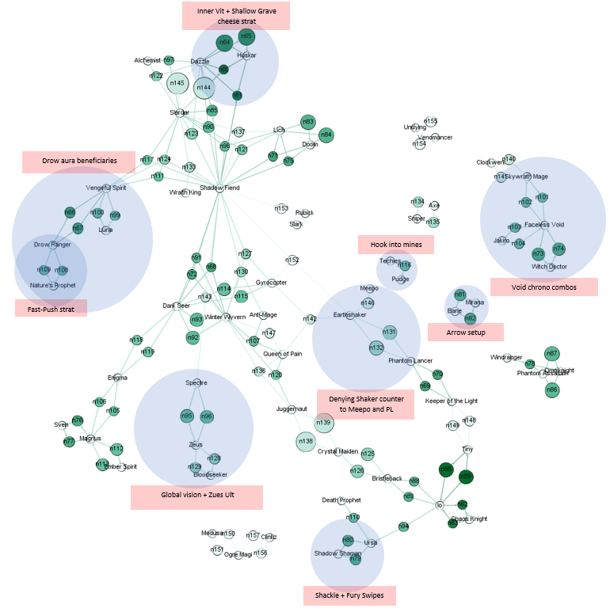

### Rules associated with 1 Hero

Here we will look at rules associated with 1 hero - Legion Commander

```r
# finding subsets of rules containing Legion Commander
legion_rules <- subset(dota_rules, items %in% "Legion Commander")
inspect(legion_rules)
```

|  | lhs |  | rhs | support | confidence | lift | count |
| --- | --- | --- | --- | --- | --- | --- | --- |
| [1] | {Skywrath Mage} | => | {Legion Commander} | 0.003232263 | 0.10857143 | 1.2028318 | 323 |
| [2] | {Legion Commander} | => | {Skywrath Mage} | 0.003232263 | 0.03580931 | 1.2028318 | 323 |
| [3] | {Storm Spirit} | => | {Legion Commander} | 0.002411688 | 0.10020790 | 1.1101747 | 241 |
| [4] | {Legion Commander} | => | {Storm Spirit} | 0.002411688 | 0.02671840 | 1.1101747 | 241 |
| [5] | {Legion Commander} | => | {Sniper} | 0.003762634 | 0.04168514 | 1.0944815 | 376 |
| [6] | {Sniper} | => | {Legion Commander} | 0.003762634 | 0.09879138 | 1.0944815 | 376 |
| [7] | {Tinker} | => | {Legion Commander} | 0.002551786 | 0.09770115 | 1.0824031 | 255 |
| [8] | {Legion Commander} | => | {Tinker} | 0.002551786 | 0.02827051 | 1.0824031 | 255 |
| [9] | {Legion Commander} | => | {Invoker} | 0.010917642 | 0.12095344 | 1.0358996 | 1091 |
| [10] | {Invoker} | => | {Legion Commander} | 0.010917642 | 0.09350360 | 1.0358996 | 1091 |

[output cut: 148 more lines]

We can see the top 10 rules by Lift

```r
inspect(legion_rules[1:10])
```

|  | lhs |  | rhs | support | confidence | lift | count |
| --- | --- | --- | --- | --- | --- | --- | --- |
| [1] | {Skywrath Mage} | => | {Legion Commander} | 0.003232263 | 0.10857143 | 1.202832 | 323 |
| [2] | {Legion Commander} | => | {Skywrath Mage} | 0.003232263 | 0.03580931 | 1.202832 | 323 |
| [3] | {Storm Spirit} | => | {Legion Commander} | 0.002411688 | 0.10020790 | 1.110175 | 241 |
| [4] | {Legion Commander} | => | {Storm Spirit} | 0.002411688 | 0.02671840 | 1.110175 | 241 |
| [5] | {Legion Commander} | => | {Sniper} | 0.003762634 | 0.04168514 | 1.094481 | 376 |
| [6] | {Sniper} | => | {Legion Commander} | 0.003762634 | 0.09879138 | 1.094481 | 376 |
| [7] | {Tinker} | => | {Legion Commander} | 0.002551786 | 0.09770115 | 1.082403 | 255 |
| [8] | {Legion Commander} | => | {Tinker} | 0.002551786 | 0.02827051 | 1.082403 | 255 |
| [9] | {Legion Commander} | => | {Invoker} | 0.010917642 | 0.12095344 | 1.035900 | 1091 |
| [10] | {Invoker} | => | {Legion Commander} | 0.010917642 | 0.09350360 | 1.035900 | 1091 |

Sizing nodes by support and colouring nodes by lift, we can see a very high lift for skywrath mage, and a high lift with tinker, storm spirit and sniper.  
These rules appear to be reciprocal in direction, i.e. a player is as likely to recognise an opportunity to pick skywrath after seeing a legion commander pick, as a player is to recognise an opportunity to pick legion commander after a skywrath pick. This would not necessarily be the case if players who play legion commander, tend to place more value the combo more than skywrath players.

We can also see a high support in rules that contain pudge or invoker, and a fairly high lift. The support statistic alone does not provide much insight, since the heroes invoker and pudge are popular anyway, but together with a fairly high lift, this translates to these heroes being expected to be seen at an even higher rate when paired with legion commander, than in an average game.

Some perceived hero associations might be very hard to infer, and may involve map positioning, farm priority, early game effectiveness and many other factors, however the most common associations with Legion Commander are fairly well known. Legion Commander’s “Duel” ability, allows her to fight an opponent in a fixed position for a lengthy period of time, providing a long disable in a small area. Heroes that can provide enormous damage in a small area of effect, which can otherwise be hard to execute due to an enemies movement, benefit greatly from Legion Commander’s “Duel” ability. Skywrath mage’s “Mystic Flare”, Storm Spirit’s “Ball Lightning” and Invoker’s “Sun Strike” are all prime examples of this.

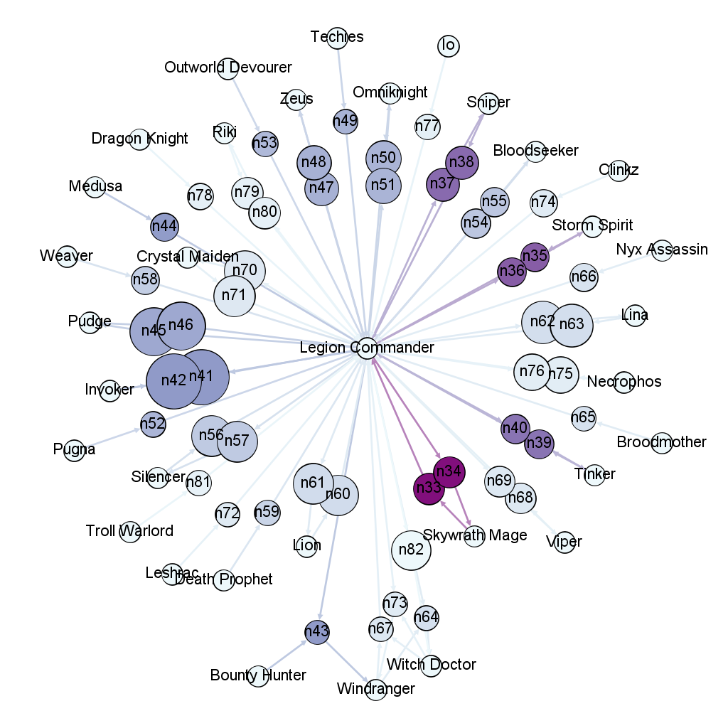

Top 50 rules containing Legion Commander by Lift

### Rules containing 3 Heroes

This section contains a brief analysis of association rules involving 3 heroes

```r
# Subsetting rules containing 3 items
# rules_2_items <- subset(dota_rules, size(rhs) == 2|size(lhs) == 2)
rules_3_items <- subset(dota_rules, size(items) == 3)
```

We can see the highest lift association rules containing 3 heroes in the below table

```r
inspect(rules_3_items[1:10])
```

|  | lhs |  | rhs | support | confidence | lift | count |
| --- | --- | --- | --- | --- | --- | --- | --- |
| [1] | {Huskar,Slardar} | => | {Dazzle} | 0.001010707 | 0.27297297 | 3.247403 | 101 |
| [2] | {Huskar,Shadow Fiend} | => | {Dazzle} | 0.001190834 | 0.24040404 | 2.859949 | 119 |
| [3] | {Shadow Fiend,Winter Wyvern} | => | {Dark Seer} | 0.001180827 | 0.08115543 | 1.922680 | 118 |
| [4] | {Lich,Shadow Fiend} | => | {Doom} | 0.001220855 | 0.14914425 | 1.879443 | 122 |
| [5] | {Dark Seer,Shadow Fiend} | => | {Winter Wyvern} | 0.001180827 | 0.14199759 | 1.844990 | 118 |
| [6] | {Doom,Shadow Fiend} | => | {Lich} | 0.001220855 | 0.08431237 | 1.799901 | 122 |
| [7] | {Phantom Assassin,Windranger} | => | {Omniknight} | 0.001130792 | 0.08855799 | 1.715371 | 113 |
| [8] | {Dazzle,Shadow Fiend} | => | {Slardar} | 0.002671870 | 0.17871486 | 1.598262 | 267 |
| [9] | {Shadow Fiend,Slardar} | => | {Dazzle} | 0.002671870 | 0.12690114 | 1.509670 | 267 |
| [10] | {Dark Seer,Winter Wyvern} | => | {Shadow Fiend} | 0.001180827 | 0.24894515 | 1.463961 | 118 |

The below graph shows these interactions, with nodes sized by support and coloured by lift

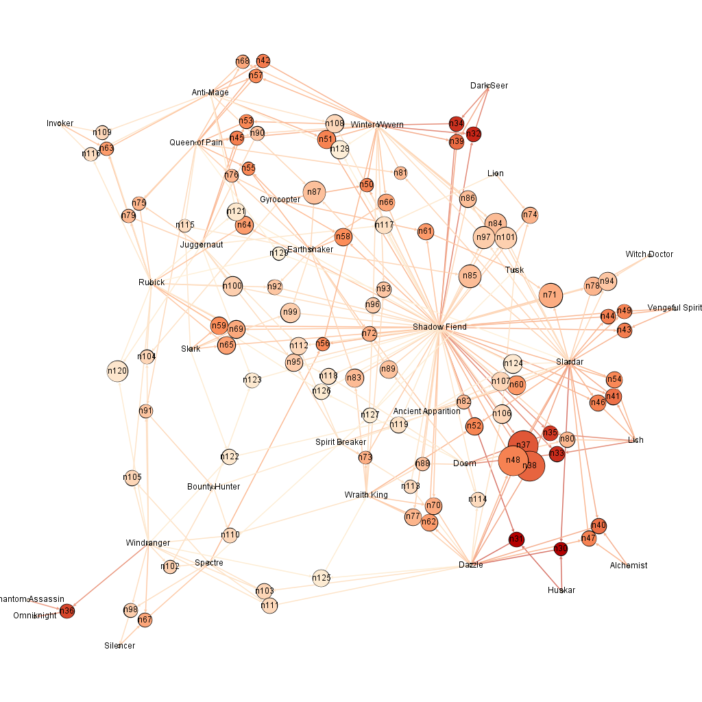

It can be difficult to differentiate interactions that involve 3 or more items in total from an increased effect of already known synergies (the combination of 2 existing synergies), or newly significant effects only achieved at a 3 item level.  
This is one of the difficulties in interpreting item basket analysis.

In an example of item basket analysis on groceries, consider the following 2 potential cases: case 1:  
if there were a rule saying yogurt ==> berries and yogurt ==> nuts, it may be the case that there is also an interaction yogurt ==> berries & nuts.  
case 2: If instead consumers very rarely purchase more than one addition with yogurt - they would either buy yogurt and berries or yogurt and nuts, a 3 item rule would not exist.

The same logic can be applied to DOTA heroes. Taking Huskar as an example, there are very strong association rules between Huskar and Dazzle, and moderately strong association rules between Huskar and Omniknight. However it is unlikely that there is a strong 3 item association rule between these heroes, since both Dazzle and Omniknight are generally considered “support heroes”, performing a similar role in a game, and as such, are unlikely to appear on the same team.

Association rules with Omniknight are in the below table, as items 5 and 6 of Huskar’s association rules

```r
# finding subsets of rules containing Huskar
huskar_rules <- subset(dota_rules, items %in% "Huskar")
inspect(huskar_rules)
```

|  | lhs |  | rhs | support | confidence | lift | count |
| --- | --- | --- | --- | --- | --- | --- | --- |
| [1] | {Huskar,Slardar} | => | {Dazzle} | 0.001010707 | 0.27297297 | 3.2474035 | 101 |
| [2] | {Huskar,Shadow Fiend} | => | {Dazzle} | 0.001190834 | 0.24040404 | 2.8599495 | 119 |
| [3] | {Huskar} | => | {Dazzle} | 0.007745422 | 0.20470775 | 2.4352911 | 774 |
| [4] | {Dazzle} | => | {Huskar} | 0.007745422 | 0.09214286 | 2.4352911 | 774 |
| [5] | {Huskar} | => | {Omniknight} | 0.002351646 | 0.06215287 | 1.2039031 | 235 |
| [6] | {Omniknight} | => | {Huskar} | 0.002351646 | 0.04555146 | 1.2039031 | 235 |
| [7] | {Abaddon} | => | {Huskar} | 0.001190834 | 0.03597340 | 0.9507595 | 119 |
| [8] | {Huskar} | => | {Abaddon} | 0.001190834 | 0.03147316 | 0.9507595 | 119 |
| [9] | {Huskar} | => | {Necrophos} | 0.002121485 | 0.05606982 | 0.9394798 | 212 |
| [10] | {Necrophos} | => | {Huskar} | 0.002121485 | 0.03554661 | 0.9394798 | 212 |

[output cut: 88 more lines]

However in the next table showing Huskar’s association rules involving 3 or more items, Omniknight is not present

```r
# finding subsets of rules of 3 or more items containing Huskar
huskar_rules_3_items <- subset(rules_3_items, items %in% "Huskar")
inspect(huskar_rules_3_items)
```

|  | lhs |  | rhs | support | confidence | lift | count |
| --- | --- | --- | --- | --- | --- | --- | --- |
| [1] | {Huskar,Slardar} | => | {Dazzle} | 0.001010707 | 0.272973 | 3.247403 | 101 |
| [2] | {Huskar,Shadow Fiend} | => | {Dazzle} | 0.001190834 | 0.240404 | 2.859949 | 119 |

### Explaining Specific 3 Hero Association Rules

The below items show individual directional 3 hero interactions, either caused by a enhanced combination of a known 2 hero interaction, or a new interaction.

The Dazzle-Slardar-Shadow Fiend interaction below is likely due to all 3 heroes reducing enemy armour. In DOTA, armour debuffs increase hero damage *exponentially* rather than *proportionally*, therefore a 3 hero interaction is to be expected.

[figure not shown]

The Dazzle-Huskar-Slardar interaction, unlike the Dazzle-Huskar-Omniknight interaction previously discussed, is likely to be feasible here due to the 3 heroes occupying different roles, rather than sharing 1 role such as hard-support as before. The cause of the third level interaction is unknown, though a higher rater player may be able to understand a synergy between these heroes.

[figure not shown]

### Note on Data Interpretation

Since the Data was obtained from 50,000 matches, which is only a moderately sized Database, there is the risk of vulnerability to noise. As an example, some players queue for games in parties of 2 or more, and some players favour picking from a very limited hero pool, or even the same hero many games in a row (a practice known as “spamming”).  
The following 3 item association rule may be the result of a perceived synergy between the 3 heroes, generated from a number of random matches, or it may be an anomalous result of 3 people queuing for games together and picking their preferred hero each time.

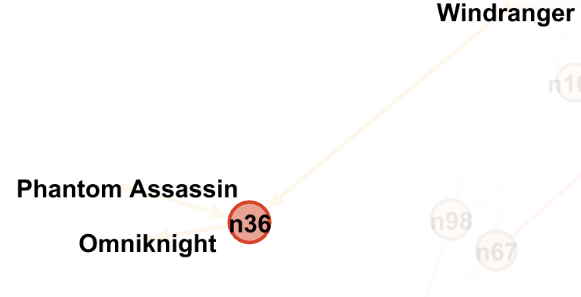

Continuing with the example of Windranger, Omniknight and Phantom Assassin, a support of 0.001130792 implies 113 teams in which the three heroes appear together, which is a low enough value to be influenced by individual party members spamming heroes without thought of any perceived association rules.

|  | lhs |  | rhs | support | confidence | lift | count |
| --- | --- | --- | --- | --- | --- | --- | --- |
| [1] | {Phantom Assassin,Windranger} | => | {Omniknight} | 0.001130792 | 0.08855799 | 1.7153713 | 113 |
| [2] | {Silencer,Windranger} | => | {Spectre} | 0.001090764 | 0.08038348 | 1.2066578 | 109 |
| [3] | {Queen of Pain,Windranger} | => | {Bounty Hunter} | 0.001050736 | 0.07882883 | 1.1604839 | 105 |
| [4] | {Spectre,Windranger} | => | {Silencer} | 0.001090764 | 0.08295282 | 1.1478088 | 109 |
| [5] | {Spectre,Windranger} | => | {Bounty Hunter} | 0.001020715 | 0.07762557 | 1.1427701 | 102 |
| [6] | {Dazzle,Windranger} | => | {Spectre} | 0.001250876 | 0.07571169 | 1.1365283 | 125 |
| [7] | {Gyrocopter,Windranger} | => | {Rubick} | 0.001110778 | 0.09296482 | 1.1359715 | 111 |
| [8] | {Spectre,Windranger} | => | {Rubick} | 0.001220855 | 0.09284627 | 1.1345228 | 122 |
| [9] | {Bounty Hunter,Wraith King} | => | {Windranger} | 0.001170820 | 0.23636364 | 1.1318136 | 117 |
| [10] | {Spectre,Windranger} | => | {Dazzle} | 0.001250876 | 0.09512938 | 1.1316998 | 125 |

[output cut: 46 more lines]